# Practice 1: Programming Basics

This Jupyter notebook introduces a healthcare data set that we will be using to practice for the duration of the workshop.

#### Instructions

This notebook includes a framework for loading and inspecting data in the example healthcare data set. Skeleton code for the analysis is provided for you. Your job is to fill in missing code denoted by ellipses (`...`) in the notebook. Each ellipse includes a commented `TODO` statement above it with instructions. Please fill in the missing code in the notebook.

#### Scope

This notebook includes material covered in Lecture 1: Programming Basics. You will have a chance to…

1. Assign variable
2. Load data into a table
3. Visualize the data set

#### Data Description

> Jason Walonoski, Mark Kramer, Joseph Nichols, Andre Quina, Chris Moesel, Dylan Hall, Carlton Duffett, Kudakwashe Dube, Thomas Gallagher, Scott McLachlan, Synthea: An approach, method, and software mechanism for generating synthetic patients and the synthetic electronic health care record, Journal of the American Medical Informatics Association, Volume 25, Issue 3, March 2018, Pages 230–238, https://doi.org/10.1093/jamia/ocx079

The data may be downloaded by clicking [this](https://synthetichealth.github.io/synthea-sample-data/downloads/synthea_sample_data_csv_apr2020.zip) hyperlink. **Please ensure that all tables are stored subdirectory called “data” placed immediately inside the directory containing this notebook.** In this example, we will be working with patient records stored in `patients.csv`.

#### Import Modules

```r
library(ggplot2)
```

#### Assign Variable

We will be working with the `patients.csv` file in this example. In the subsequent code block, you will specify the location of the data table. To do so, you will assign the value `"data/patients.csv"` to the variable `path`.

```r
# TODO: Assign the value "data/patients.csv" to the variable `path`
path <- "data/patients.csv"
```

#### Load Data into a Table

During lecture 2, you will learn more about data frames. Briefly, data frames are tables of data. Below, we provide the code for loading the data in `patients.csv` into a data frame.

```r
# Load the table using read.csv
df_patient <- read.csv(path, header = TRUE)
```

Let’s take a look at the data using the `print` command.

```r
# Print the table of patient data
print(df_patient)
```

```
##                                        Id  BIRTHDATE
## 1    1d604da9-9a81-4ba9-80c2-de3375d59b40 1989-05-25
## 2    034e9e3b-2def-4559-bb2a-7850888ae060 1983-11-14
## 3    10339b10-3cd1-4ac3-ac13-ec26728cb592 1992-06-02
## 4    8d4c4326-e9de-4f45-9a4c-f8c36bff89ae 1978-05-27
## 5    f5dcd418-09fe-4a2f-baa0-3da800bd8c3a 1996-10-18
## 6    72c0b9ce-7aa4-430b-aaff-bd0ce7846e55 2017-07-27
## 7    b1e9b0b9-da6e-4f68-b603-bd896a50ca86 2003-12-13
## 8    01207ecd-9dff-4754-8887-4652eda231e2 2019-05-15
## 9    b58731cc-2d8b-4c2d-b327-4cab771af3ef 1970-05-16
## 10   cfee79fc-df05-476e-b274-43e09ea345db 2016-07-04
## 11   ad2e9916-4979-40fc-a8c0-68651a0cb5a6 2004-12-19
## 12   bfb6537b-535a-4f31-9a56-073220f96a17 1991-07-03
## 13   83719bd7-7a41-4c87-93f9-c5de4db6a14a 1989-06-07
## 14   76982e06-f8b8-4509-9ca3-65a99c8650fe 1982-09-01
```

[output cut: 10533 more lines]

#### Visualize the Data Set

Let’s start by inspecting the distribution of healthcare expenses among patients. Below we use ggplot2 to plot a histogram of the healthcare expenses, which are stored in the `HEALTHCARE_EXPENSES` column of `df_patient`.

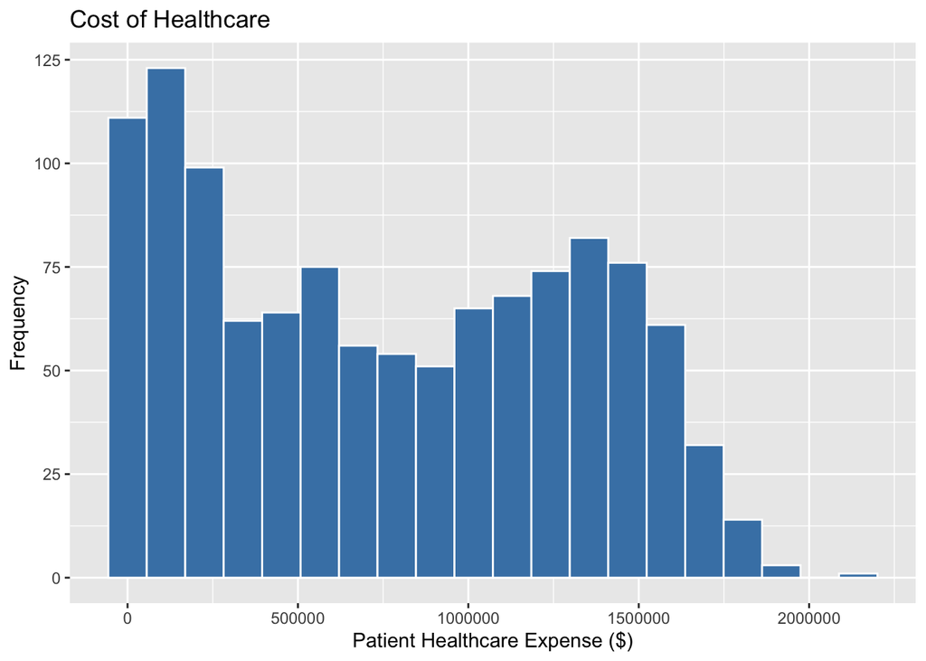

```r
# Plot a histogram of healthcare expenses
# TODO: Provide appropriate x and y labels for the histogram
# TODO: Provide an appropriate title for the histogram
ggplot(df_patient, aes(x = HEALTHCARE_EXPENSES)) +
  geom_histogram(fill = "steelblue", color = "white", bins = 20) +
  labs(title = "Cost of Healthcare",
       x = "Patient Healthcare Expense ($)",
       y = "Frequency")
```

Please comment on the distribution of healthcare expenses.

**POSSIBLE ANS.** Generally speaking, healthcare expenses appear to have a rightward skew. Few patients appear to have particularly high expenses. The distribution of healthcare expenses also appears to be bimodal, with peaks near $100,000 and $1.3M.

We can simplify the theme of our figure by adding `theme_minimal()` to our plotting code.

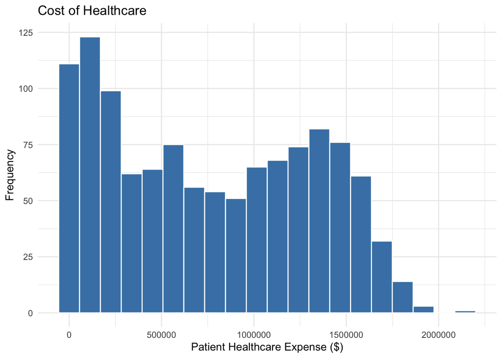

```r
# Plot a histogram of healthcare expenses using a simple theme
# TODO: Provide appropriate x and y labels for the histogram
# TODO: Provide an appropriate title for the histogram
ggplot(df_patient, aes(x = HEALTHCARE_EXPENSES)) +
  geom_histogram(fill = "steelblue", color = "white", bins = 20) +
  labs(title = "Cost of Healthcare",
       x = "Patient Healthcare Expense ($)",
       y = "Frequency") +
  theme_minimal()
```

Now, let’s visualize the distribution of race in the data set. Since race is a categorical attribute, we can visualize the distribution of race using a bar chart. We will use the built-in `table` function to generate a count of each race. We will then represent these counts in a data frame. Finally, we will plot our bar chart. Built-in functions and data frames will be discussed in more detail during lecture 2.

```r
# Generate a count of each race in the `df_patient` table.
# We will introduce data frames in more detail during lecture 2. For now, just consider data frames as a way to represent tables in R.
counts <- table(df_patient$RACE)
counts <- as.data.frame(counts)

# Print the counts of each race
print(counts)
```

```
##     Var1 Freq
## 1  asian   90
## 2  black  101
## 3 native   13
## 4  other    2
## 5  white  965
```

```r
# For convenience, the following line of code assigns the row labels "race" and "count" in the `counts` table.
names(counts) <- c("race", "count")

# You will be better able to understand the code after we introduce vectors during lecture 2. For now, just notice what happens when we re-print the table.
print(counts)
```

```
##     race count
## 1  asian    90
## 2  black   101
## 3 native    13
## 4  other     2
## 5  white   965
```

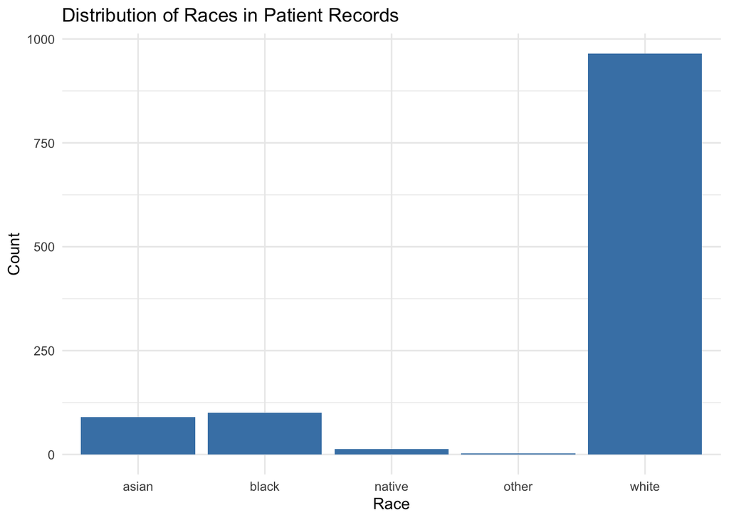

```r
# Plot a bar chart to visualize the distribution of races
# TODO: Provide appropriate x and y labels for the bar chart
# TODO: Provide an appropriate title for the bar chart
ggplot(counts, aes(x = race, y = count)) +
  geom_col(fill = "steelblue") +
  labs(title = "Distribution of Races in Patient Records",
       x = "Race",
       y = "Count") +
  theme_minimal()
```

Please comment on the distribution of races in the data set. It is important to account for imbalanced representation in the data set when using the data to develop models (however, model development is beyond the scope of this course).

**Possible ANS.** Most patients in the data set belong to the `white` race category.

#### Advanced Plotting (just for fun)

Notice, all patients appear to come from Massachusetts. To demonstrate the capabilities of ggplot2, let’s generate a heatmap to visualize which counties are most represented in the dataset. You do not need to worry about implementing this yourself! The code makes use of a third-party `maps` package that enables us to overlay a heatmap on the map of the US.

```r
# Install the `maps` package
# Uncomment the line below if you receive an error saying that `maps` is not installed.
# install.packages("maps")

# Load the `maps` package
library(maps)
```

```r
# Count the frequency that each state appears in the data set
county_counts <- table(df_patient$COUNTY)
county_counts <- as.data.frame(county_counts)

# For convenience, rename the column labels in `state_counts`
names(county_counts) <- c("county", "count")
print(county_counts)
```

```
##               county count
## 1  Barnstable County    47
## 2   Berkshire County    24
## 3     Bristol County   105
## 4       Dukes County     5
## 5       Essex County   115
## 6    Franklin County    15
## 7     Hampden County    80
## 8   Hampshire County    35
## 9   Middlesex County   255
## 10  Nantucket County     2
## 11    Norfolk County   128
## 12   Plymouth County    78
## 13    Suffolk County   132
## 14  Worcester County   150
```

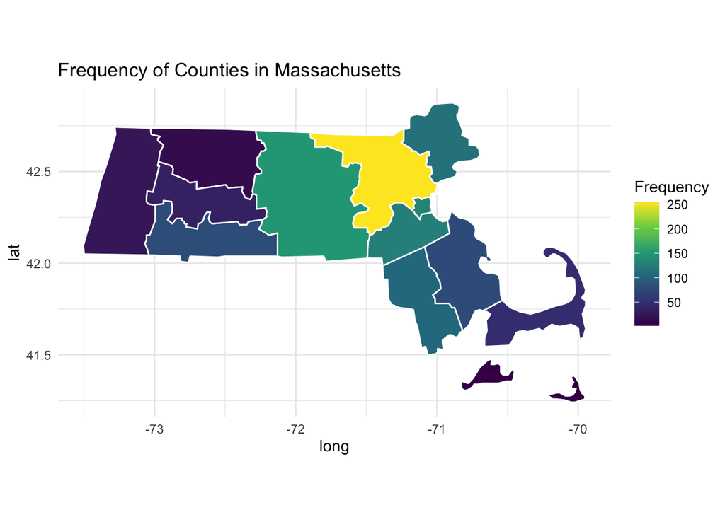

```r
# Don't worry about the rest of this code! This is for demonstration purposes only!

# Get the boundaries of Massachusetts counties using the `maps` package
ma_counties <- map("county", "massachusetts", fill = TRUE, plot = FALSE)
ma_counties_df <- fortify(ma_counties, region = "names")

## Relabel the row labels in `county_counts` so they are consistent with the `ma_counties_df`
county_counts$county <- as.character(county_counts$county)
county_counts$county <- gsub("county", "", tolower(county_counts$county))
county_counts$county <- trimws(county_counts$county)

# Overlay the county frequency data on the Massachusetts map
county_map_data <- merge(ma_counties_df, county_counts, by.x = "subregion", by.y = "county", all.x = TRUE)

# Visualize the state frequencies as a heatmap
ggplot(county_map_data, aes(x = long, y = lat, group = group, fill = count)) +
  geom_polygon(color = "white") +
  coord_fixed(1.3) +  # Aspect ratio for the map
  labs(title = "Frequency of Counties in Massachusetts",
       fill = "Frequency") +
  theme_minimal() +
  scale_fill_viridis_c()
```

#### Summary

In this demonstration, we loaded and inspected a table of patient information. We visualized the distribution of healthcare expenses using a histogram, patient races using a bar plot, and patient location using a heatmap. The hands-on portion of this first demonstration is light. In future demonstrations, as you grow more familiar with the R syntax, you will have a chance to practice loading and manipulating data yourself!